# Practice portfolio: change in Dutch sentence production

# Purpose and data

This is a reproducibility practice example, not a model assessment answer. The code is complete so the report can be rendered from an extracted project. You supply the interpretation and reflection; the example is not a portfolio to submit.

The teaching extract comes from the longitudinal sentence-production experiment reported by Lieburg et al. (2023). Active and passive sentences are alternatives, not incorrect and correct answers. Each summary row represents one learner, one study session, one prompt condition and one phase, combining four recorded target trials. The same people appear repeatedly. The trial-level file is supplied so the summaries can be traced and response categories examined.

The baseline subset includes 17 learners in 164 summary rows. The first three figures use the number of full passive responses out of four recorded target trials in each cell (0–4). Other responses and no response remain among those four trials. The average across learners can be fractional. This differs from the article’s main binary analyses, which exclude those categories. It is not a reproduction of the published percentages or statistical models. See data/README.md for coding, source and preparation.

# Average change over study sessions

Figure 1 shows the mean number of full passive responses out of four trials for each session and phase. Missing learner sessions are not filled with zero; the people contributing can differ slightly across sessions.

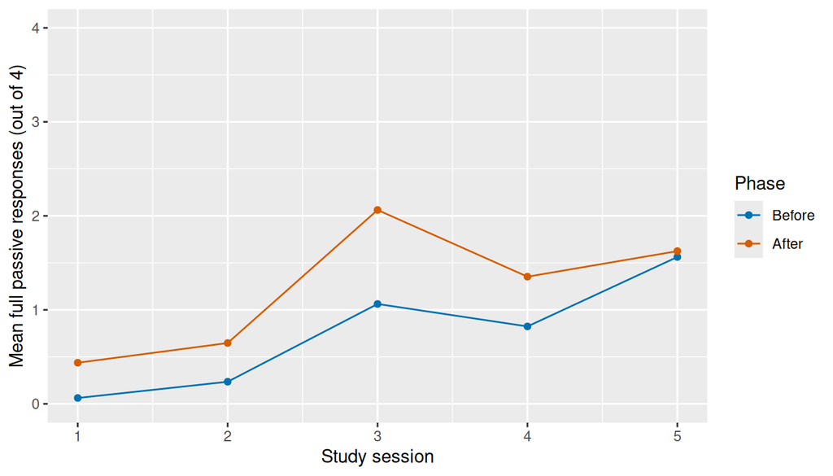

Figure 1: Mean participant counts of full passive responses out of four trials after baseline prompts, before and after the within-session intervention. Each learner contributes a count from 0 to 4. Lines connect observed means, not fitted learning curves.

# Variation at the final study session

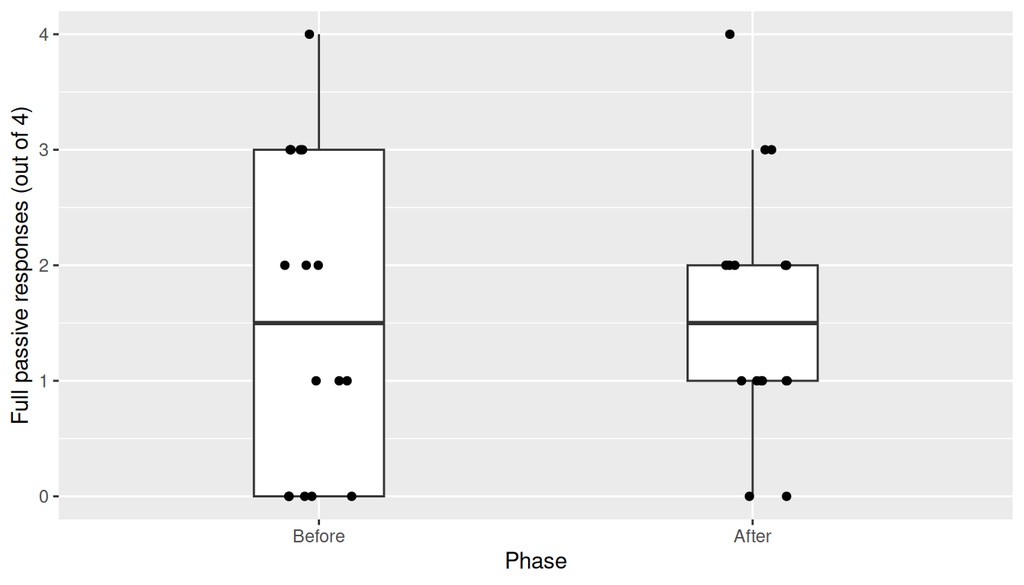

Figure 2: Participant counts of full passive responses out of four trials at Session 5 after baseline prompts. Boxes summarise medians and quartiles; points retain the observed counts. Before and After are repeated observations of the same learners, although the boxplots do not display their pairing.

# Individual patterns across sessions

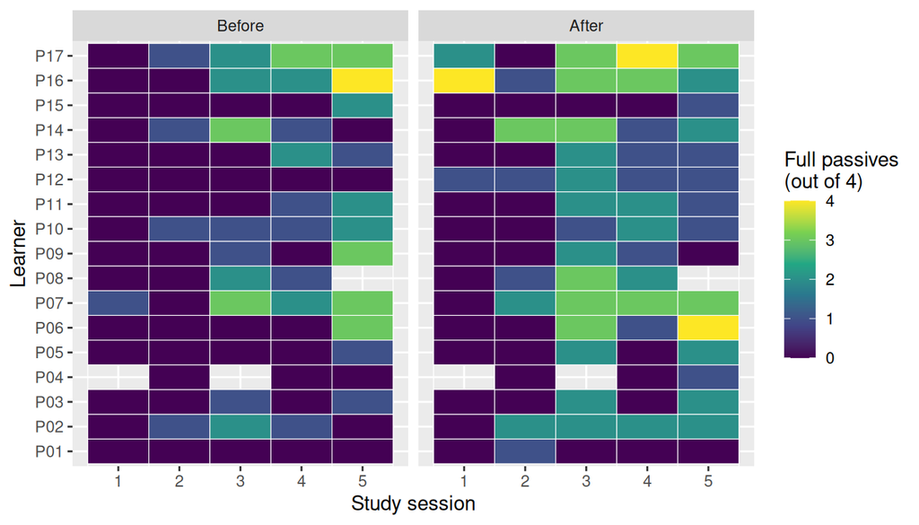

Figure 3: One tile per observed learner, session and phase after baseline prompts. Colour shows the number of full passive responses out of four target trials. Missing tiles are unobserved sessions, not zero counts.

# What happens to the other responses?

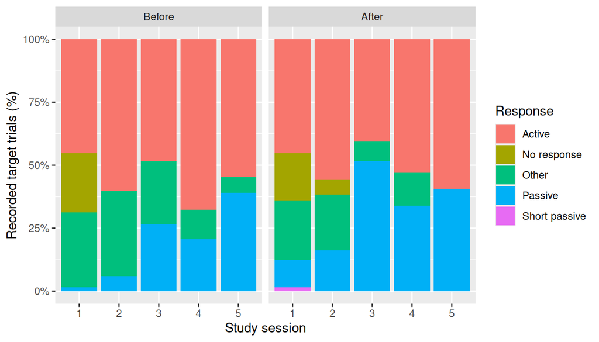

Figure 4: Response-category proportions after baseline prompts in each session and phase. All recorded target trials contribute, including other responses, short passives and no response. These are repeated trials, not independent learners.

# Dashboard

The separate app in app.R lets users choose prompt conditions, phases and a vocabulary-score range, and compares the average with individual patterns. It uses the shared-preparation and tab patterns described by Wickham (2021). Run it with Run App; stop it before rendering the report again.

# Reflection

# Reproducibility information

The report and app load their packages independently and use relative paths. The report and root-level app both read data/ from the project root. Keep report.Rmd, app.R and the Rproj file together so Console checks, knitting and Run App use the same relative paths. The dictionary identifies the source files and supplied preparation. This example does not require the authors’ model-fitting packages.

# References

Lieburg, R. van, Sijyeniyo, E., Hartsuiker, R. J., & Bernolet, S. (2023). The development of abstract syntactic representations in beginning L2 learners of Dutch. *Journal of Cultural Cognitive Science*, *7*, 289–309. https://doi.org/10.1007/s41809-023-00131-5

Wickham, H. (2021). *Mastering shiny*. O’Reilly Media. https://mastering-shiny.org